# SISBID: Causal Inference with Machine Learning

R version

# 1 Average Treatment Effect Estimation

For unit $i$, let

- $Y_i^{(1)}$ be the potential outcome under treatment;
- $Y_i^{(0)}$ be the potential outcome under control;
- $T_i \in \{0,1\}$ be the treatment indicator.

The average treatment effect is

$$\tau = \mathbb{E}\left[Y_i^{(1)} - Y_i^{(0)}\right].$$

For each unit, we observe only one potential outcome:

$$Y_i = T_iY_i^{(1)} + (1-T_i)Y_i^{(0)}.$$

# 2 Randomized Treatment

We first consider randomized treatment assignment, so that

$$\left(Y_i^{(1)},Y_i^{(0)}\right) \perp T_i.$$

```r
n_randomized <- 500

# Randomly assign treatment
randomized_t <- rbinom(
  n = n_randomized,
  size = 1,
  prob = 0.5
)

# True treatment effect
randomized_tau <- 4

# Observed outcome
randomized_y <- randomized_tau * randomized_t +
  rnorm(n_randomized)

randomized_data <- data.frame(
  unit = seq_len(n_randomized),
  t = factor(randomized_t, levels = c(0, 1)),
  y = randomized_y
)
```

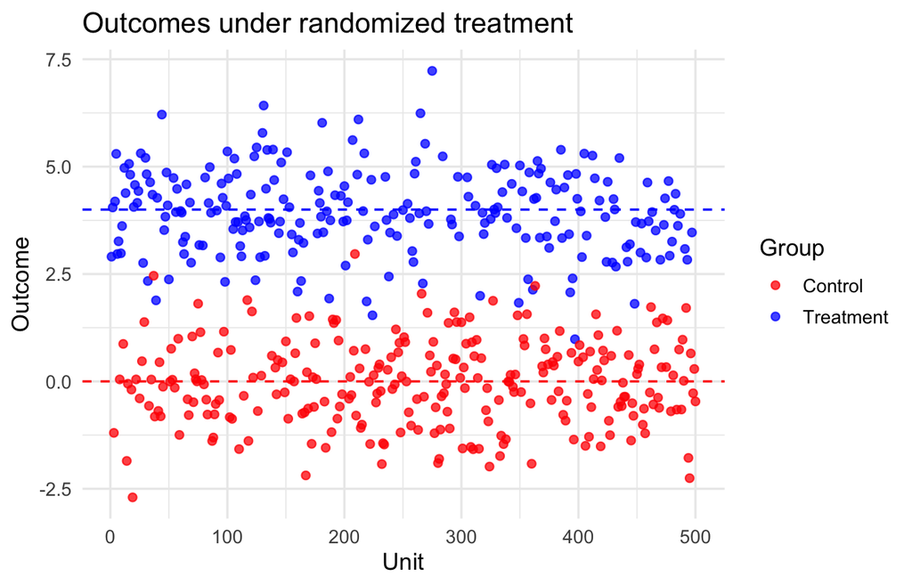

```r
ggplot(
  randomized_data,
  aes(x = unit, y = y, color = t)
) +
  geom_point(alpha = 0.75) +
  geom_hline(
    yintercept = 0,
    linetype = "dashed",
    color = "red"
  ) +
  geom_hline(
    yintercept = randomized_tau,
    linetype = "dashed",
    color = "blue"
  ) +
  scale_color_manual(
    values = c("0" = "red", "1" = "blue"),
    labels = c("Control", "Treatment")
  ) +
  labs(
    x = "Unit",
    y = "Outcome",
    color = "Group",
    title = "Outcomes under randomized treatment"
  )
```

Under random assignment,

$$\mathbb{E}[Y_i \mid T_i=1]
-
\mathbb{E}[Y_i \mid T_i=0]
=
\mathbb{E}[Y_i^{(1)}-Y_i^{(0)}].$$

Thus, the ATE can be estimated using the difference in sample means.

```r
randomized_difference_ate <-
  mean(randomized_y[randomized_t == 1]) -
  mean(randomized_y[randomized_t == 0])

randomized_difference_ate
```

```
## [1] 3.982143
```

The same estimate is the coefficient of $T$ in a linear regression with an intercept.

```r
randomized_model <- lm(
  randomized_y ~ randomized_t
)

randomized_regression_ate <-
  coef(randomized_model)[["randomized_t"]]

coef(randomized_model)
```

```
##  (Intercept) randomized_t
##  -0.04153351   3.98214313
```

```r
summary(randomized_model)
```

```
##
## Call:
## lm(formula = randomized_y ~ randomized_t)
##
## Residuals:
##     Min      1Q  Median      3Q     Max
## -2.9585 -0.6327  0.0139  0.6932  3.2885
##
## Coefficients:
##              Estimate Std. Error t value Pr(>|t|)
## (Intercept)  -0.04153    0.06024  -0.689    0.491
## randomized_t  3.98214    0.08787  45.320   <2e-16 ***
## ---
## Signif. codes:  0 '***' 0.001 '**' 0.01 '*' 0.05 '.' 0.1 ' ' 1
##
## Residual standard error: 0.9806 on 498 degrees of freedom
## Multiple R-squared:  0.8048, Adjusted R-squared:  0.8045
## F-statistic:  2054 on 1 and 498 DF,  p-value: < 2.2e-16
```

# 3 Observed Confounder

Suppose $X$ affects both treatment assignment and the outcome. If the outcome model is linear, we may estimate the treatment effect using

$$Y_i = \alpha + \beta X_i + \tau T_i + \varepsilon_i.$$

```r
n_confounder <- 500

confounder_x <- runif(
  n_confounder,
  min = -3,
  max = 3
)

# Treatment is determined by X
confounder_t <- as.integer(confounder_x < 0)

confounder_tau <- 4

confounder_y <- confounder_x +
  confounder_tau * confounder_t +
  rnorm(n_confounder)

confounded_data <- data.frame(
  x = confounder_x,
  t = factor(confounder_t, levels = c(0, 1)),
  y = confounder_y
)
```

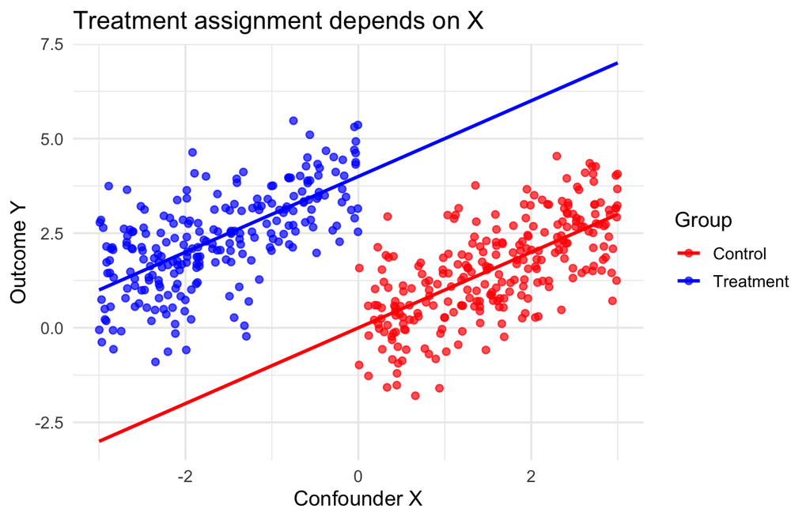

```r
confounder_line_data <- data.frame(
  x = rep(
    seq(-3, 3, length.out = 200),
    2
  ),
  t = factor(
    rep(c(0, 1), each = 200),
    levels = c(0, 1)
  )
)

confounder_line_data$mean_y <-
  confounder_line_data$x +
  confounder_tau *
    as.numeric(
      as.character(confounder_line_data$t)
    )

ggplot(
  confounded_data,
  aes(x = x, y = y, color = t)
) +
  geom_point(alpha = 0.7) +
  geom_line(
    data = confounder_line_data,
    aes(x = x, y = mean_y, color = t),
    linewidth = 1
  ) +
  scale_color_manual(
    values = c("0" = "red", "1" = "blue"),
    labels = c("Control", "Treatment")
  ) +
  labs(
    x = "Confounder X",
    y = "Outcome Y",
    color = "Group",
    title = "Treatment assignment depends on X"
  )
```

If we fail to adjust for $X$, the difference in means is biased.

```r
confounder_unadjusted_ate <-
  mean(confounder_y[confounder_t == 1]) -
  mean(confounder_y[confounder_t == 0])

confounder_unadjusted_ate
```

```
## [1] 0.8136807
```

Adjusting for $X$ using linear regression recovers the treatment effect.

```r
adjusted_model <- lm(
  confounder_y ~ confounder_t + confounder_x
)

adjusted_ate <-
  coef(adjusted_model)[["confounder_t"]]

coef(adjusted_model)
```

```
##  (Intercept) confounder_t confounder_x
##   -0.0434034    4.0043469    0.9955943
```

```r
summary(adjusted_model)
```

```
##
## Call:
## lm(formula = confounder_y ~ confounder_t + confounder_x)
##
## Residuals:
##      Min       1Q   Median       3Q      Max
## -2.89513 -0.62448  0.00875  0.64739  2.66004
##
## Coefficients:
##              Estimate Std. Error t value Pr(>|t|)
## (Intercept)  -0.04340    0.09983  -0.435    0.664
## confounder_t  4.00435    0.18419  21.740   <2e-16 ***
## confounder_x  0.99559    0.05071  19.635   <2e-16 ***
## ---
## Signif. codes:  0 '***' 0.001 '**' 0.01 '*' 0.05 '.' 0.1 ' ' 1
##
## Residual standard error: 0.9688 on 497 degrees of freedom
## Multiple R-squared:  0.4879, Adjusted R-squared:  0.4859
## F-statistic: 236.8 on 2 and 497 DF,  p-value: < 2.2e-16
```

```r
adjusted_ate
```

```
## [1] 4.004347
```

## 3.1 Frisch–Waugh–Lovell Residualization

The coefficient of $T$ in the regression of $Y$ on $T$ and $X$ can also be obtained by:

1. residualizing $Y$ with respect to $X$;
2. residualizing $T$ with respect to $X$;
3. regressing the residualized outcome on the residualized treatment.

```r
outcome_residual <- resid(
  lm(confounder_y ~ confounder_x)
)

treatment_residual <- resid(
  lm(confounder_t ~ confounder_x)
)

fwl_model <- lm(
  outcome_residual ~ 0 + treatment_residual
)

fwl_ate <-
  coef(fwl_model)[["treatment_residual"]]

coef(fwl_model)
```

```
## treatment_residual
##           4.004347
```

```r
c(
  regression_adjustment = adjusted_ate,
  FWL_residualization = fwl_ate
)
```

```
## regression_adjustment   FWL_residualization
##              4.004347              4.004347
```

# 4 Propensity Score

The propensity score is

$$q(X_i)=\Pr(T_i=1\mid X_i).$$

Inverse probability weighting can identify the ATE when treatment is conditionally independent of the potential outcomes given $X$, and when overlap holds:

$$0 < q(X_i) < 1.$$

## 4.1 Simulate Data with Overlap

```r
n_propensity <- 500

propensity_x <- runif(
  n_propensity,
  min = -3,
  max = 3
)

# True propensity score
true_propensity <- plogis(propensity_x)

propensity_t <- rbinom(
  n_propensity,
  size = 1,
  prob = true_propensity
)

propensity_tau <- 4

propensity_y <- propensity_x +
  propensity_tau * propensity_t +
  rnorm(n_propensity)

propensity_data <- data.frame(
  x = propensity_x,
  t = factor(propensity_t, levels = c(0, 1)),
  y = propensity_y,
  true_propensity = true_propensity
)

range(true_propensity)
```

```
## [1] 0.04865486 0.95252836
```

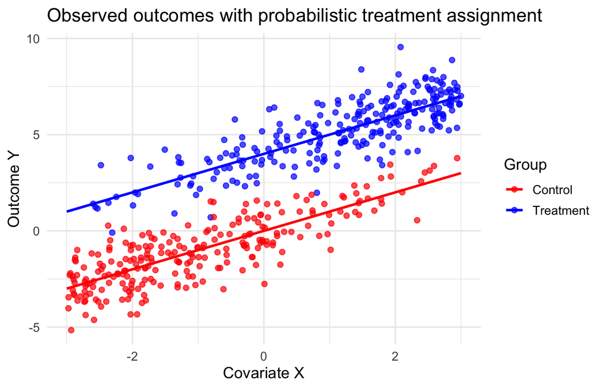

```r
propensity_line_data <- data.frame(
  x = rep(
    seq(-3, 3, length.out = 200),
    2
  ),
  t = factor(
    rep(c(0, 1), each = 200),
    levels = c(0, 1)
  )
)

propensity_line_data$mean_y <-
  propensity_line_data$x +
  propensity_tau *
    as.numeric(
      as.character(propensity_line_data$t)
    )

ggplot(
  propensity_data,
  aes(x = x, y = y, color = t)
) +
  geom_point(alpha = 0.7) +
  geom_line(
    data = propensity_line_data,
    aes(x = x, y = mean_y, color = t),
    linewidth = 1
  ) +
  scale_color_manual(
    values = c("0" = "red", "1" = "blue"),
    labels = c("Control", "Treatment")
  ) +
  labs(
    x = "Covariate X",
    y = "Outcome Y",
    color = "Group",
    title = paste(
      "Observed outcomes with probabilistic",
      "treatment assignment"
    )
  )
```

## 4.2 Estimate the Propensity Score

In practice, the true propensity score is unknown. We estimate it by fitting a logistic regression of treatment on $X$.

```r
propensity_model <- glm(
  propensity_t ~ propensity_x,
  family = binomial(link = "logit")
)

estimated_propensity <- predict(
  propensity_model,
  type = "response"
)

summary(propensity_model)
```

```
##
## Call:
## glm(formula = propensity_t ~ propensity_x, family = binomial(link = "logit"))
##
## Coefficients:
##              Estimate Std. Error z value Pr(>|z|)
## (Intercept)  -0.03392    0.11398  -0.298    0.766
## propensity_x  0.93653    0.08001  11.705   <2e-16 ***
## ---
## Signif. codes:  0 '***' 0.001 '**' 0.01 '*' 0.05 '.' 0.1 ' ' 1
##
## (Dispersion parameter for binomial family taken to be 1)
##
##     Null deviance: 692.95  on 499  degrees of freedom
## Residual deviance: 476.74  on 498  degrees of freedom
## AIC: 480.74
##
## Number of Fisher Scoring iterations: 4
```

```r
range(estimated_propensity)
```

```
## [1] 0.05634161 0.94129370
```

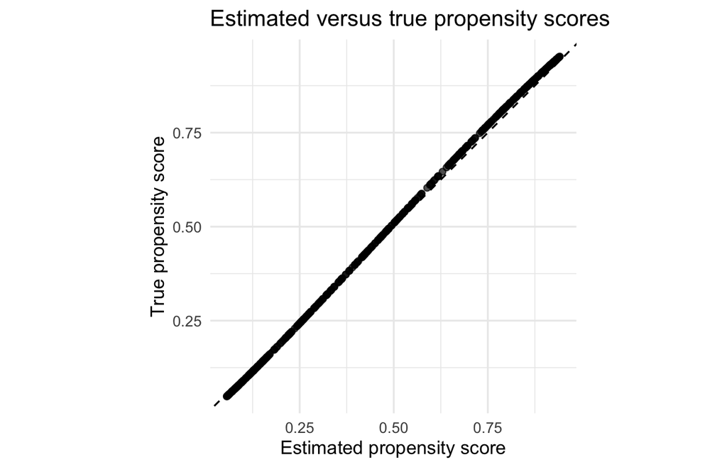

```r
propensity_comparison <- data.frame(
  estimated = estimated_propensity,
  truth = true_propensity
)

ggplot(
  propensity_comparison,
  aes(x = estimated, y = truth)
) +
  geom_point(alpha = 0.7) +
  geom_abline(
    intercept = 0,
    slope = 1,
    linetype = "dashed"
  ) +
  coord_equal() +
  labs(
    x = "Estimated propensity score",
    y = "True propensity score",
    title = "Estimated versus true propensity scores"
  )
```

## 4.3 Inverse Probability Weighting

The Horvitz–Thompson IPW estimator is

$$\widehat{\tau}_{\mathrm{IPW}}
=
\frac{1}{n}
\sum_{i=1}^n
\left[
\frac{T_iY_i}{\widehat q(X_i)}
-
\frac{(1-T_i)Y_i}{1-\widehat q(X_i)}
\right].$$

```r
ipw_contribution <-
  propensity_t * propensity_y /
    estimated_propensity -
  (1 - propensity_t) * propensity_y /
    (1 - estimated_propensity)

ipw_ate <- mean(ipw_contribution)

ipw_ate
```

```
## [1] 4.086595
```

A normalized Hájek version can be more stable in finite samples:

```r
treated_mean_ipw <-
  sum(
    propensity_t * propensity_y /
      estimated_propensity
  ) /
  sum(
    propensity_t / estimated_propensity
  )

control_mean_ipw <-
  sum(
    (1 - propensity_t) * propensity_y /
      (1 - estimated_propensity)
  ) /
  sum(
    (1 - propensity_t) /
      (1 - estimated_propensity)
  )

hajek_ate <- treated_mean_ipw - control_mean_ipw

hajek_ate
```

```
## [1] 4.0777
```

# 5 Colliders

A collider is a variable caused by two other variables. In the following simulation,

$$T \longrightarrow X \longleftarrow Y.$$

Conditioning on $X$ opens a noncausal association between $T$ and $Y$. Therefore, we should not adjust for $X$.

## 5.1 Collider Example with a Positive Treatment Effect

```r
n_collider_positive <- 500

collider_positive_t <- rbinom(
  n_collider_positive,
  size = 1,
  prob = 0.5
)

collider_positive_tau <- 4

collider_positive_y <-
  collider_positive_tau * collider_positive_t +
  rnorm(n_collider_positive)

# X is a collider affected by both T and Y
collider_positive_x <-
  collider_positive_t +
  0.5 * collider_positive_y +
  rnorm(n_collider_positive, sd = 0.2)
```

Without conditioning on the collider, the difference in means estimates the ATE.

```r
collider_positive_unadjusted_ate <-
  mean(
    collider_positive_y[
      collider_positive_t == 1
    ]
  ) -
  mean(
    collider_positive_y[
      collider_positive_t == 0
    ]
  )

collider_positive_unadjusted_ate
```

```
## [1] 3.952224
```

Conditioning on the collider can severely bias the estimate.

```r
collider_positive_model <- lm(
  collider_positive_y ~
    collider_positive_t +
    collider_positive_x
)

collider_positive_adjusted_ate <-
  coef(
    collider_positive_model
  )[["collider_positive_t"]]

coef(collider_positive_model)
```

```
##         (Intercept) collider_positive_t collider_positive_x
##         -0.04451905         -1.18962322          1.75215055
```

```r
summary(collider_positive_model)
```

```
##
## Call:
## lm(formula = collider_positive_y ~ collider_positive_t + collider_positive_x)
##
## Residuals:
##      Min       1Q   Median       3Q      Max
## -1.20040 -0.25012  0.00639  0.26378  1.18627
##
## Coefficients:
##                     Estimate Std. Error t value Pr(>|t|)
## (Intercept)         -0.04452    0.02470  -1.803   0.0721 .
## collider_positive_t -1.18962    0.09662 -12.312   <2e-16 ***
## collider_positive_x  1.75215    0.03081  56.863   <2e-16 ***
## ---
## Signif. codes:  0 '***' 0.001 '**' 0.01 '*' 0.05 '.' 0.1 ' ' 1
##
## Residual standard error: 0.3802 on 497 degrees of freedom
## Multiple R-squared:  0.9711, Adjusted R-squared:  0.971
## F-statistic:  8352 on 2 and 497 DF,  p-value: < 2.2e-16
```

## 5.2 Collider Example with No Treatment Effect

Here, the true treatment effect is zero.

```r
n_collider_zero <- 500

collider_zero_t <- rbinom(
  n_collider_zero,
  size = 1,
  prob = 0.5
)

collider_zero_tau <- 0

collider_zero_y <-
  collider_zero_tau * collider_zero_t +
  rnorm(n_collider_zero)

collider_zero_x <-
  collider_zero_t +
  0.5 * collider_zero_y +
  rnorm(n_collider_zero, sd = 0.2)
```

The unadjusted difference in means is approximately unbiased for the zero ATE.

```r
collider_zero_unadjusted_ate <-
  mean(
    collider_zero_y[collider_zero_t == 1]
  ) -
  mean(
    collider_zero_y[collider_zero_t == 0]
  )

collider_zero_unadjusted_ate
```

```
## [1] -0.05631068
```

Conditioning on the collider creates a spurious treatment association.

```r
collider_zero_model <- lm(
  collider_zero_y ~
    collider_zero_t +
    collider_zero_x
)

collider_zero_adjusted_ate <-
  coef(collider_zero_model)[["collider_zero_t"]]

coef(collider_zero_model)
```

```
##     (Intercept) collider_zero_t collider_zero_x
##     0.009684631    -1.769470323     1.744119700
```

```r
summary(collider_zero_model)
```

```
##
## Call:
## lm(formula = collider_zero_y ~ collider_zero_t + collider_zero_x)
##
## Residuals:
##      Min       1Q   Median       3Q      Max
## -1.01734 -0.24253 -0.01396  0.24161  1.29522
##
## Coefficients:
##                  Estimate Std. Error t value Pr(>|t|)
## (Intercept)      0.009685   0.022670   0.427    0.669
## collider_zero_t -1.769470   0.043420 -40.753   <2e-16 ***
## collider_zero_x  1.744120   0.028979  60.186   <2e-16 ***
## ---
## Signif. codes:  0 '***' 0.001 '**' 0.01 '*' 0.05 '.' 0.1 ' ' 1
##
## Residual standard error: 0.3662 on 497 degrees of freedom
## Multiple R-squared:  0.8794, Adjusted R-squared:  0.879
## F-statistic:  1813 on 2 and 497 DF,  p-value: < 2.2e-16
```

# 6 Summary of Estimators

```r
results <- data.frame(
  example = c(
    "Randomized: difference in means",
    "Randomized: linear regression",
    "Confounded: unadjusted",
    "Confounded: regression adjustment",
    "Confounded: FWL residualization",
    "Propensity score: Horvitz--Thompson IPW",
    "Propensity score: Hájek IPW",
    "Collider, positive effect: unadjusted",
    "Collider, positive effect: adjusted",
    "Collider, zero effect: unadjusted",
    "Collider, zero effect: adjusted"
  ),
  estimate = c(
    randomized_difference_ate,
    randomized_regression_ate,
    confounder_unadjusted_ate,
    adjusted_ate,
    fwl_ate,
    ipw_ate,
    hajek_ate,
    collider_positive_unadjusted_ate,
    collider_positive_adjusted_ate,
    collider_zero_unadjusted_ate,
    collider_zero_adjusted_ate
  )
)

knitr::kable(
  results,
  digits = 3,
  col.names = c(
    "Method",
    "Estimated treatment effect"
  )
)
```

| Method | Estimated treatment effect |
| --- | --- |
| Randomized: difference in means | 3.982 |
| Randomized: linear regression | 3.982 |
| Confounded: unadjusted | 0.814 |
| Confounded: regression adjustment | 4.004 |
| Confounded: FWL residualization | 4.004 |
| Propensity score: Horvitz–Thompson IPW | 4.087 |
| Propensity score: Hájek IPW | 4.078 |
| Collider, positive effect: unadjusted | 3.952 |
| Collider, positive effect: adjusted | -1.190 |
| Collider, zero effect: unadjusted | -0.056 |
| Collider, zero effect: adjusted | -1.769 |